# Homework #6

Dustin Leatherman

3/11/2020

# 1

> The Proactive Kids Foundation was founded in 2008 by Tony Burke as an early intervention and nonprofit organization with the mission of improving body composition, physical strength, body image and self-esteem in children. According to Burke, “kids alone can’t turn their lives around,” so it is necessary to involve the family as part of the intervention to change the child’s environment.

> The PAK Program utilizes a three-tiered approach to make changes in the child’s environment; fitness, nutrition and lifestyle coaching with the goal of educating parents or caregivers along with the child on the topics of mental health coaching (i.e., lifestyle), fitness, and nutrition to impact variables affecting body composition for long-term sustainability. The ProActive kids data consists of 884 children. The data was collected between 2010 to 2017. All children were between 5 to 17 years of age and resided in four Illinois counties.

**Body Composition**: Height (inches), weight (pounds), body fat (percent), fat free mass (FFM) and BMI and were obtained during week 1 and week 8.

## a

> Does the program designed by the ProActive Kids Foundation improve the body composition of the children?

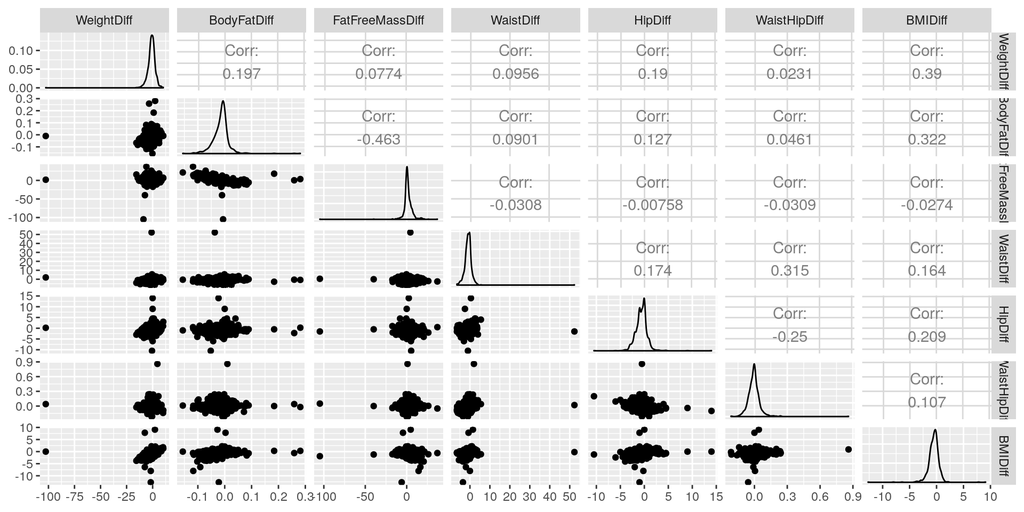

```r
kids <- read.csv("~/Downloads/kid_PAK.csv")
kids.plus <-
  kids %>%
  as_tibble() %>%
  mutate(
    WeightDiff = Week_8_Weight - Week_1_Weight,
    BodyFatDiff = Week_8_Body_Fat - Week_1_Body_Fat,
    FatFreeMassDiff = Week_8_Fat_Free_Mass - Week_1_Fat_Free_Mass,
    WaistDiff = Week_8_Waist - Week_1Waist,
    HipDiff = Week_8_Hip - Week_1_Hip,
    WaistHipDiff = Week_8_Waist_Hip_Ratio - Week_1_Waist_Hip_Ratio,
    BMIDiff = Ending_BMI - Starting_BMI,
    Sex = toupper(Sex)
  )

kids.plus %>%
  select(WeightDiff, BodyFatDiff, FatFreeMassDiff, WaistDiff, HipDiff, WaistHipDiff, BMIDiff) %>%
  ggpairs()
```

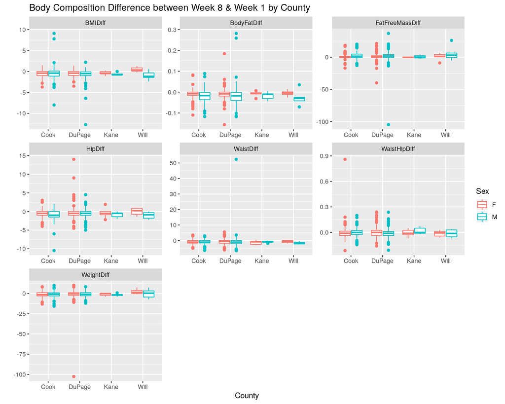

```r
# boxplots for each difference variable
kids.plus %>%
  select(WeightDiff, BodyFatDiff, FatFreeMassDiff, WaistDiff, HipDiff, WaistHipDiff, BMIDiff, Sex, County_in_IL) %>%
  gather(c(-Sex, -County_in_IL), key = "variable", value = "value") %>%
  ggplot(aes(y = value, x = County_in_IL, color = Sex)) +
    geom_boxplot() +
    facet_wrap(~ variable , ncol = 3, scales = "free") +
    ylab("") +
    xlab("County") +
    ggtitle("Body Composition Difference between Week 8 & Week 1 by County")
```

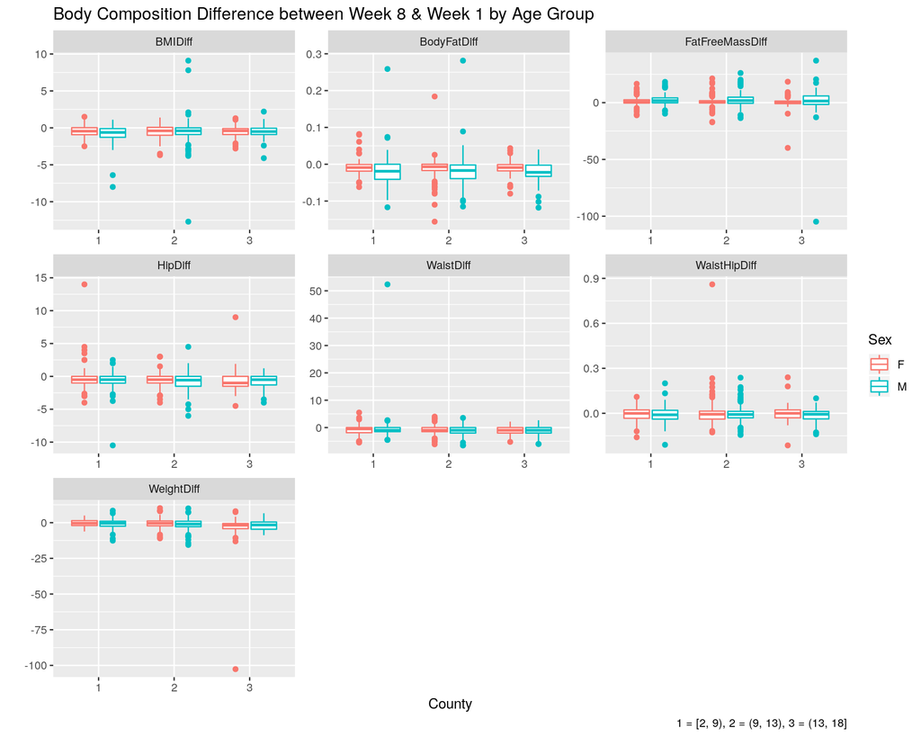

```r
kids.plus %>%
  select(WeightDiff, BodyFatDiff, FatFreeMassDiff, WaistDiff, HipDiff, WaistHipDiff, BMIDiff, Sex, age_group) %>%
  gather(c(-Sex, -age_group), key = "variable", value = "value") %>%
  ggplot(aes(y = value, x = factor(age_group), color = Sex)) +
    geom_boxplot() +
    facet_wrap(~ variable , ncol = 3, scales = "free") +
    ylab("") +
    xlab("County") +
    ggtitle("Body Composition Difference between Week 8 & Week 1 by Age Group") +
    labs(caption = "1 = [2, 9), 2 = (9, 13), 3 = (13, 18]")
```

By county, males have a larger range of composition differences compared to Females for Body Fat, Fat Free Mass, and Hip. The genders are similar in spread for Waist, Waist Hip, BMI, and Weight differences. The counties don’t appear to have any noticable effect on body composition differences.

By Age Group, Males have a larger spread in Body Fat change compared to females. However, the spread and center values appear to be similar across age ranges. This indicates that Age Group is likely not a significant contributing factor to body composition loss.

Based on the above graphs, I suspect that the program does not have a significant effect on body composition for most individuals.

### Assumptions

The data are multi-level. One level was removed by calculating the difference between Week 1 and Week 8 (thus removing the longitidunal portion of the model). The levels are as follows:

**Level 1**

- Body Composition Differences
- Gender
- Age

**Level 2**

- County
- age_group

The boxplots hint at the variances between genders differing but it can be confirmed with Levene’s Test.

```r
levene.test(kids.plus$BodyFatDiff, group = kids.plus$Sex)
```

```
##
##  Modified robust Brown-Forsythe Levene-type test based on the absolute
##  deviations from the median
##
## data:  kids.plus$BodyFatDiff
## Test Statistic = 54.114, p-value = 4.319e-13
```

While only one variable is shown, all body composition differences result in heteroscedascity. When modeling, Sex will modeled with heroscedastic variances.

Since each participant comes from a county, this will be represented as a *Random Effect* within the models. Age, Sex, and their interaction will be treated as *Fixed Effects* as those are the primary independent variables of interest.

### Weight

```r
kids.m.weight1 <- lme(WeightDiff ~ Age * Sex, random = ~1 | County_in_IL, kids.plus, method = "REML", weights = varIdent(form = ~1 | Sex))
kids.m.weight1 %>% summary
```

```
## Linear mixed-effects model fit by REML
##  Data: kids.plus
##        AIC      BIC    logLik
##   5162.848 5196.323 -2574.424
##
## Random effects:
##  Formula: ~1 | County_in_IL
##          (Intercept) Residual
## StdDev: 0.0001805634 5.685343
##
## Variance function:
##  Structure: Different standard deviations per stratum
##  Formula: ~1 | Sex
##  Parameter estimates:
##         F         M
## 1.0000000 0.6038167
## Fixed effects: WeightDiff ~ Age * Sex
##                 Value Std.Error  DF   t-value p-value
## (Intercept)  3.207723 1.1199111 879  2.864266  0.0043
## Age         -0.411073 0.1047923 879 -3.922745  0.0001
## SexM        -3.293791 1.3022163 879 -2.529373  0.0116
## Age:SexM     0.304470 0.1220874 879  2.493870  0.0128
##  Correlation:
##          (Intr) Age    SexM
## Age      -0.970
## SexM     -0.860  0.834
## Age:SexM  0.833 -0.858 -0.970
##
## Standardized Within-Group Residuals:
##          Min           Q1          Med           Q3          Max
## -17.50148991  -0.36877229   0.04189108   0.46395725   3.30686808
##
## Number of Observations: 886
## Number of Groups: 4
```

```r
kids.m.weight2 <- lme(WeightDiff ~ Age * Sex, random = ~1 | County_in_IL, kids.plus, method = "REML")

anova(kids.m.weight1, kids.m.weight2) %>% as_tibble() %>% select(-call) %>% kable
```

| Model | df | AIC | BIC | logLik | Test | L.Ratio | p-value |
| --- | --- | --- | --- | --- | --- | --- | --- |
| 1 | 7 | 5162.848 | 5196.323 | -2574.424 |  | NA | NA |
| 2 | 6 | 5268.852 | 5297.545 | -2628.426 | 1 vs 2 | 108.0045 | 0 |

```r
intervals(kids.m.weight1)
```

```
## Approximate 95% confidence intervals
##
##  Fixed effects:
##                   lower       est.      upper
## (Intercept)  1.00971127  3.2077231  5.4057350
## Age         -0.61674558 -0.4110733 -0.2054011
## SexM        -5.84960735 -3.2937911 -0.7379749
## Age:SexM     0.06485322  0.3044701  0.5440870
## attr(,"label")
## [1] "Fixed effects:"
##
##  Random Effects:
##   Level: County_in_IL
##                        lower         est.        upper
## sd((Intercept)) 4.546314e-51 0.0001805634 7.171333e+42
##
##  Variance function:
##       lower      est.     upper
## M 0.5499922 0.6038167 0.6629087
## attr(,"label")
## [1] "Variance function:"
##
##  Within-group standard error:
##    lower     est.    upper
## 5.321017 5.685343 6.074614
```

The model accounting for heroscedasticity in Sex and without. The AIC and BIC values indicate that accounting the heterosceastic model is a better fit. County doesnt appear to affect the model due to its small intercept value but the fixed effects are all signficant.

### Body Fat

```r
kids.m.bfat1 <- lme(BodyFatDiff ~ Age * Sex, random = ~1 | County_in_IL, kids.plus, method = "REML", weights = varIdent(form = ~1 | Sex))
kids.m.bfat1 %>% summary
```

```
## Linear mixed-effects model fit by REML
##  Data: kids.plus
##         AIC       BIC   logLik
##   -3732.056 -3698.581 1873.028
##
## Random effects:
##  Formula: ~1 | County_in_IL
##          (Intercept)  Residual
## StdDev: 2.534778e-07 0.0222665
##
## Variance function:
##  Structure: Different standard deviations per stratum
##  Formula: ~1 | Sex
##  Parameter estimates:
##        F        M
## 1.000000 1.630617
## Fixed effects: BodyFatDiff ~ Age * Sex
##                    Value   Std.Error  DF    t-value p-value
## (Intercept) -0.007682595 0.004386104 879 -1.7515762  0.0802
## Age         -0.000216930 0.000410416 879 -0.5285605  0.5972
## SexM        -0.010642338 0.008284482 879 -1.2846112  0.1993
## Age:SexM     0.000166755 0.000779347 879  0.2139672  0.8306
##  Correlation:
##          (Intr) Age    SexM
## Age      -0.970
## SexM     -0.529  0.514
## Age:SexM  0.511 -0.527 -0.970
##
## Standardized Within-Group Residuals:
##         Min          Q1         Med          Q3         Max
## -6.57327466 -0.44569013  0.07054434  0.44570512  8.70136921
##
## Number of Observations: 886
## Number of Groups: 4
```

```r
kids.m.bfat2 <- lme(BodyFatDiff ~ Age * Sex, random = ~1 | County_in_IL, kids.plus, method = "REML")

anova(kids.m.bfat1, kids.m.bfat2) %>% as_tibble() %>% select(-call) %>% kable
```

| Model | df | AIC | BIC | logLik | Test | L.Ratio | p-value |
| --- | --- | --- | --- | --- | --- | --- | --- |
| 1 | 7 | -3732.056 | -3698.581 | 1873.028 |  | NA | NA |
| 2 | 6 | -3632.791 | -3604.098 | 1822.395 | 1 vs 2 | 101.2655 | 0 |

```r
intervals(kids.m.bfat1)
```

```
## Approximate 95% confidence intervals
##
##  Fixed effects:
##                    lower          est.        upper
## (Intercept) -0.016291054 -0.0076825950 0.0009258639
## Age         -0.001022440 -0.0002169298 0.0005885804
## SexM        -0.026902013 -0.0106423382 0.0056173367
## Age:SexM    -0.001362843  0.0001667546 0.0016963524
## attr(,"label")
## [1] "Fixed effects:"
##
##  Random Effects:
##   Level: County_in_IL
##                        lower         est.        upper
## sd((Intercept)) 2.386278e-74 2.534778e-07 2.692519e+60
##
##  Variance function:
##      lower     est.   upper
## M 1.485318 1.630617 1.79013
## attr(,"label")
## [1] "Variance function:"
##
##  Within-group standard error:
##      lower       est.      upper
## 0.02083979 0.02226650 0.02379089
```

Again the model accounting for variance is superior. Going forward only this model will be used. None of the fixed terms are signficant in this context so theres nothing that can be gleaned from this model.

### Fat Free Mass

```r
kids.m.ffreemass1 <- lme(FatFreeMassDiff ~ Age * Sex, random = ~1 | County_in_IL, kids.plus, method = "REML", weights = varIdent(form = ~1 | Sex))
kids.m.ffreemass1 %>% summary
```

```
## Linear mixed-effects model fit by REML
##  Data: kids.plus
##        AIC      BIC    logLik
##   5557.137 5590.612 -2771.569
##
## Random effects:
##  Formula: ~1 | County_in_IL
##          (Intercept) Residual
## StdDev: 0.0002049374 4.146103
##
## Variance function:
##  Structure: Different standard deviations per stratum
##  Formula: ~1 | Sex
##  Parameter estimates:
##        F        M
## 1.000000 1.762465
## Fixed effects: FatFreeMassDiff ~ Age * Sex
##                  Value Std.Error  DF    t-value p-value
## (Intercept)  2.1063479 0.8167083 879  2.5790699  0.0101
## Age         -0.1147639 0.0764210 879 -1.5017334  0.1335
## SexM         1.9024794 1.6333301 879  1.1647856  0.2444
## Age:SexM    -0.0751178 0.1536867 879 -0.4887719  0.6251
##  Correlation:
##          (Intr) Age    SexM
## Age      -0.970
## SexM     -0.500  0.485
## Age:SexM  0.482 -0.497 -0.970
##
## Standardized Within-Group Residuals:
##          Min           Q1          Med           Q3          Max
## -14.45914738  -0.34112896  -0.07744787   0.28533771   4.88341821
##
## Number of Observations: 886
## Number of Groups: 4
```

```r
intervals(kids.m.ffreemass1, which = "fixed")
```

```
## Approximate 95% confidence intervals
##
##  Fixed effects:
##                  lower        est.      upper
## (Intercept)  0.5034218  2.10634791 3.70927401
## Age         -0.2647529 -0.11476395 0.03522496
## SexM        -1.3032027  1.90247939 5.10816153
## Age:SexM    -0.3767536 -0.07511776 0.22651804
## attr(,"label")
## [1] "Fixed effects:"
```

The fixed effects are not significant and the standard error of the random effects is very small.

### Waist

```r
kids.m.waist1 <- lme(WaistDiff ~ Age * Sex, random = ~1 | County_in_IL, kids.plus, method = "REML", weights = varIdent(form = ~1 | Sex))
kids.m.waist1 %>% summary
```

```
## Linear mixed-effects model fit by REML
##  Data: kids.plus
##        AIC     BIC    logLik
##   3913.345 3946.82 -1949.672
##
## Random effects:
##  Formula: ~1 | County_in_IL
##         (Intercept) Residual
## StdDev:  0.09407075 1.587838
##
## Variance function:
##  Structure: Different standard deviations per stratum
##  Formula: ~1 | Sex
##  Parameter estimates:
##        F        M
## 1.000000 1.861468
## Fixed effects: WaistDiff ~ Age * Sex
##                  Value Std.Error  DF   t-value p-value
## (Intercept) -0.5402435 0.3209685 879 -1.683167  0.0927
## Age         -0.0312176 0.0292982 879 -1.065512  0.2869
## SexM         0.9518384 0.6521699 879  1.459494  0.1448
## Age:SexM    -0.0974129 0.0613801 879 -1.587044  0.1129
##  Correlation:
##          (Intr) Age    SexM
## Age      -0.951
## SexM     -0.468  0.465
## Age:SexM  0.451 -0.476 -0.970
##
## Standardized Within-Group Residuals:
##          Min           Q1          Med           Q3          Max
## -3.368347583 -0.412603892  0.005273475  0.439070858 17.777234100
##
## Number of Observations: 886
## Number of Groups: 4
```

```r
intervals(kids.m.waist1)
```

```
## Approximate 95% confidence intervals
##
##  Fixed effects:
##                   lower        est.      upper
## (Intercept) -1.17019764 -0.54024348 0.08971067
## Age         -0.08872024 -0.03121760 0.02628504
## SexM        -0.32815362  0.95183842 2.23183045
## Age:SexM    -0.21788145 -0.09741286 0.02305574
## attr(,"label")
## [1] "Fixed effects:"
##
##  Random Effects:
##   Level: County_in_IL
##                       lower       est.    upper
## sd((Intercept)) 0.007579042 0.09407075 1.167602
##
##  Variance function:
##      lower     est.    upper
## M 1.695524 1.861468 2.043653
## attr(,"label")
## [1] "Variance function:"
##
##  Within-group standard error:
##    lower     est.    upper
## 1.485999 1.587838 1.696657
```

The fixed effects are not significant and the standard error of the random effects is very small.

### Hip

```r
kids.m.hip1 <- lme(HipDiff ~ Age * Sex, random = ~1 | County_in_IL, kids.plus, method = "REML", weights = varIdent(form = ~1 | Sex))
kids.m.hip1 %>% summary
```

```
## Linear mixed-effects model fit by REML
##  Data: kids.plus
##        AIC     BIC    logLik
##   3016.305 3049.78 -1501.153
##
## Random effects:
##  Formula: ~1 | County_in_IL
##         (Intercept) Residual
## StdDev:   0.1465308 1.373747
##
## Variance function:
##  Structure: Different standard deviations per stratum
##  Formula: ~1 | Sex
##  Parameter estimates:
##         F         M
## 1.0000000 0.9022917
## Fixed effects: HipDiff ~ Age * Sex
##                  Value Std.Error  DF    t-value p-value
## (Intercept) -0.0426223 0.2899281 879 -0.1470098  0.8832
## Age         -0.0437615 0.0253708 879 -1.7248755  0.0849
## SexM        -0.7382503 0.3618720 879 -2.0400866  0.0416
## Age:SexM     0.0458963 0.0339827 879  1.3505768  0.1772
##  Correlation:
##          (Intr) Age    SexM
## Age      -0.918
## SexM     -0.702  0.724
## Age:SexM  0.679 -0.744 -0.970
##
## Standardized Within-Group Residuals:
##         Min          Q1         Med          Q3         Max
## -7.75281273 -0.50228992  0.05761278  0.52277392 10.31635858
##
## Number of Observations: 886
## Number of Groups: 4
```

```r
intervals(kids.m.hip1)
```

```
## Approximate 95% confidence intervals
##
##  Fixed effects:
##                   lower        est.        upper
## (Intercept) -0.61165443 -0.04262228  0.526409872
## Age         -0.09355605 -0.04376155  0.006032958
## SexM        -1.44848442 -0.73825030 -0.028016177
## Age:SexM    -0.02080049  0.04589630  0.112593097
## attr(,"label")
## [1] "Fixed effects:"
##
##  Random Effects:
##   Level: County_in_IL
##                      lower      est.     upper
## sd((Intercept)) 0.04263793 0.1465308 0.5035725
##
##  Variance function:
##       lower      est.     upper
## M 0.8219528 0.9022917 0.9904832
## attr(,"label")
## [1] "Variance function:"
##
##  Within-group standard error:
##    lower     est.    upper
## 1.285804 1.373747 1.467705
```

Sex is the only parameter that is considered moderately significant.

### Waist-Hip Ratio

```r
kids.m.waisthip1 <- lme(WaistHipDiff ~ Age * Sex, random = ~1 | County_in_IL, kids.plus, method = "REML", weights = varIdent(form = ~1 | Sex))
kids.m.waisthip1 %>% summary
```

```
## Linear mixed-effects model fit by REML
##  Data: kids.plus
##         AIC       BIC   logLik
##   -2515.156 -2481.681 1264.578
##
## Random effects:
##  Formula: ~1 | County_in_IL
##          (Intercept)   Residual
## StdDev: 7.066454e-06 0.06535221
##
## Variance function:
##  Structure: Different standard deviations per stratum
##  Formula: ~1 | Sex
##  Parameter estimates:
##         F         M
## 1.0000000 0.7561438
## Fixed effects: WaistHipDiff ~ Age * Sex
##                    Value   Std.Error  DF    t-value p-value
## (Intercept) -0.019116144 0.012873220 879 -1.4849543  0.1379
## Age          0.001547237 0.001204572 879  1.2844703  0.1993
## SexM         0.013660886 0.016037946 879  0.8517852  0.3946
## Age:SexM    -0.001703553 0.001504680 879 -1.1321697  0.2579
##  Correlation:
##          (Intr) Age    SexM
## Age      -0.970
## SexM     -0.803  0.779
## Age:SexM  0.777 -0.801 -0.970
##
## Standardized Within-Group Residuals:
##         Min          Q1         Med          Q3         Max
## -4.11937028 -0.48056948 -0.02735479  0.39874188 13.15586811
##
## Number of Observations: 886
## Number of Groups: 4
```

```r
intervals(kids.m.waisthip1, which = "fixed")
```

```
## Approximate 95% confidence intervals
##
##  Fixed effects:
##                     lower         est.       upper
## (Intercept) -0.0443819813 -0.019116144 0.006149694
## Age         -0.0008169362  0.001547237 0.003911411
## SexM        -0.0178162537  0.013660886 0.045138025
## Age:SexM    -0.0046567371 -0.001703553 0.001249632
## attr(,"label")
## [1] "Fixed effects:"
```

There are no signifcant parameters.

### BMI

```r
kids.m.bmi1 <- lme(BMIDiff ~ Age * Sex, random = ~1 | County_in_IL, kids.plus, method = "REML", weights = varIdent(form = ~1 | Sex))
kids.m.bmi1 %>% summary
```

```
## Linear mixed-effects model fit by REML
##  Data: kids.plus
##        AIC      BIC   logLik
##   2538.461 2571.936 -1262.23
##
## Random effects:
##  Formula: ~1 | County_in_IL
##         (Intercept)  Residual
## StdDev: 0.007208256 0.7721343
##
## Variance function:
##  Structure: Different standard deviations per stratum
##  Formula: ~1 | Sex
##  Parameter estimates:
##        F        M
## 1.000000 1.658794
## Fixed effects: BMIDiff ~ Age * Sex
##                  Value  Std.Error  DF   t-value p-value
## (Intercept) -0.2933702 0.15220524 879 -1.927465  0.0542
## Age         -0.0147116 0.01423253 879 -1.033658  0.3016
## SexM        -0.7307012 0.29086459 879 -2.512170  0.0122
## Age:SexM     0.0566014 0.02736404 879  2.068460  0.0389
##  Correlation:
##          (Intr) Age    SexM
## Age      -0.970
## SexM     -0.523  0.507
## Age:SexM  0.504 -0.520 -0.970
##
## Standardized Within-Group Residuals:
##        Min         Q1        Med         Q3        Max
## -9.5394582 -0.4832522  0.0710996  0.5090557  7.5626362
##
## Number of Observations: 886
## Number of Groups: 4
```

```r
intervals(kids.m.bmi1, which = "fixed")
```

```
## Approximate 95% confidence intervals
##
##  Fixed effects:
##                    lower        est.        upper
## (Intercept) -0.592098375 -0.29337024  0.005357887
## Age         -0.042645289 -0.01471157  0.013222139
## SexM        -1.301571376 -0.73070119 -0.159831003
## Age:SexM     0.002894941  0.05660143  0.110307922
## attr(,"label")
## [1] "Fixed effects:"
```

The interaction between Age and Sex is significant, as well as Sex. The standard error associated with the Random Effect of County is small indicating that it hardly effects the model.

### Conclusion

There is evidence that given a childs age and gender, the PAK program does improve both BMI and Weight. A majority of the differences are negative indicating that there was a decrease between Week 1 and Week 8. This dataset contains many outliers and they were not dealt with in this case. Further analysis should mitigate them.

```r
kids.m.bmi1$fitted[,2] %>% enframe() %>% mutate(is_effective = value <= 0) %>% group_by(is_effective) %>% tally() %>% kable
```

| is_effective | n |
| --- | --- |
| TRUE | 886 |

```r
plot1 <- qplot(kids.m.bmi1$data$BMIDiff, kids.m.bmi1$fitted[,1]) + xlab("Actual BMI Difference") + ylab("Fitted BMI")

kids.m.weight1$fitted[,2] %>% enframe() %>% mutate(is_effective = value <= 0) %>% group_by(is_effective) %>% tally() %>% kable
```

| is_effective | n |
| --- | --- |
| FALSE | 69 |
| TRUE | 817 |

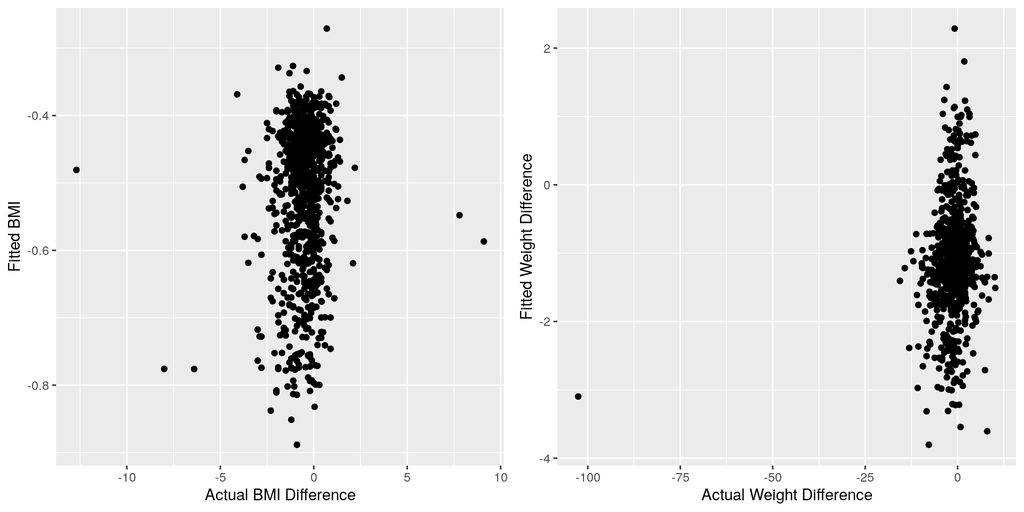

```r
plot2 <- qplot(kids.m.weight1$data$WeightDiff, kids.m.weight1$fitted[,1]) + xlab("Actual Weight Difference") + ylab("Fitted Weight Difference")

grid.arrange(plot1, plot2, ncol = 2)
```

## b

> Is there any significant difference among the four counties?

There is no significant difference between the four counties. The Boxplots show them to be fairly similar and all models showed that the coefficients associated with the four counties were very small.

# II

> The data used in this exercise were originally reported by Douglas et al (2004) and the data was reproduced by West et al (2012). The main goal of their experiment was to examine nucleotide activation (guanine nucleotide bonding) in seven different brain nuclei (i.e . brain regions) among five adults male rats The basal nucleotide activation, measured after treatment with saline solution, was compared to activation in the same region after treatment with the drug carbachol. Activation was measured as the mean optical density produced by autoradiography.

> We want to compare activation in a subset of three of the original seven brain regions studied by the authors: the bed nucleus of the stria terminals (BST), the lateral septum (LS) , and the diagonal band of Broca (VDB). The original data layout for this study is shown below. Use an appropriate statistical model to examine the nucleotide activation.

```r
activate <- read.table("~/Downloads/ratbrain.txt", header = TRUE)

activate %>% head %>% kable
```

| animal | treatment | region | activate |
| --- | --- | --- | --- |
| R111097 | 1 | 1 | 366.19 |
| R111097 | 1 | 2 | 199.31 |
| R111097 | 1 | 3 | 187.11 |
| R111097 | 2 | 1 | 371.71 |
| R111097 | 2 | 2 | 302.02 |
| R111097 | 2 | 3 | 449.70 |

This is a Multi-level dataset with three levels: Region, Treatment, and animal respectively.

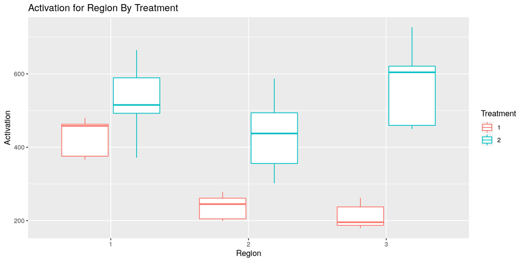

```r
activate %>%
  ggplot(aes(y = activate, x = factor(region), color = factor(treatment))) +
    geom_boxplot() +
    ylab("Activation") +
    xlab("Region") +
    ggtitle("Activation for Region By Treatment") +
    # This is strange but it changes the legend text
    labs(color = "Treatment")
```

Activation is higher in all regions in Treatment 2 compared to Treatment 1. Treatment 2 also seems to have a greater spread than Treatment 1. Thus the treatments can be treated as separate variances. Though this should be compared to a model where region is treated with separate variances. Region, Treatment, and their interaction will be treated as fixed effects since we most interested in them. The animal itself should be treated as a random effect since there will be some measure of correlation between observations on the same animal.

```r
activate.m.t1 <- lme(activate ~ factor(region) * factor(treatment), random = ~1 | animal, activate, method = "REML", weights = varIdent(form = ~1 | factor(treatment)))
summary(activate.m.t1)
```

```
## Linear mixed-effects model fit by REML
##  Data: activate
##       AIC      BIC    logLik
##   285.187 295.7895 -133.5935
##
## Random effects:
##  Formula: ~1 | animal
##         (Intercept) Residual
## StdDev:     40.1177 21.25381
##
## Variance function:
##  Structure: Different standard deviations per stratum
##  Formula: ~1 | factor(treatment)
##  Parameter estimates:
##        1        2
## 1.000000 3.896054
## Fixed effects: activate ~ factor(region) * factor(treatment)
##                                       Value Std.Error DF    t-value p-value
## (Intercept)                         428.506  20.30347 20  21.105062  0.0000
## factor(region)2                    -190.762  13.44209 20 -14.191395  0.0000
## factor(region)3                    -216.212  13.44209 20 -16.084701  0.0000
## factor(treatment)2                   98.204  38.23234 20   2.568611  0.0183
## factor(region)2:factor(treatment)2   99.322  54.06869 20   1.836960  0.0811
## factor(region)3:factor(treatment)2  261.822  54.06869 20   4.842396  0.0001
##  Correlation:
##                                    (Intr) fctr(r)2 fct()3 fctr(t)2 f()2:(
## factor(region)2                    -0.331
## factor(region)3                    -0.331  0.500
## factor(treatment)2                 -0.116  0.176    0.176
## factor(region)2:factor(treatment)2  0.082 -0.249   -0.124 -0.707
## factor(region)3:factor(treatment)2  0.082 -0.124   -0.249 -0.707    0.500
##
## Standardized Within-Group Residuals:
##        Min         Q1        Med         Q3        Max
## -1.5941411 -0.6358639  0.0947552  0.2780940  1.6094257
##
## Number of Observations: 30
## Number of Groups: 5
```

All the variables are considered signficant except for the interaction between treatment 2 and region 2. The standard error associated with the animal ranges between 18.7665 and 85.7607 with 95% confidence. This indicates that the animal a treatment is applied may have a noticable effect on the level of activation.

```r
activate.m.t2 <- lme(activate ~ factor(region) * factor(treatment), random = ~1 | animal, activate, method = "REML", weights = varIdent(form = ~1 | factor(region)))

anova(activate.m.t1, activate.m.t2) %>% as_tibble %>% select(-call) %>% kable
```

| Model | df | AIC | BIC | logLik | Test | L.Ratio | p-value |
| --- | --- | --- | --- | --- | --- | --- | --- |
| 1 | 9 | 285.1870 | 295.7895 | -133.5935 |  | NA | NA |
| 2 | 10 | 295.1756 | 306.9561 | -137.5878 | 1 vs 2 | 7.988565 | 0.0047074 |

```r
intervals(activate.m.t1)
```

```
## Approximate 95% confidence intervals
##
##  Fixed effects:
##                                         lower     est.     upper
## (Intercept)                         386.15370  428.506  470.8583
## factor(region)2                    -218.80171 -190.762 -162.7223
## factor(region)3                    -244.25171 -216.212 -188.1723
## factor(treatment)2                   18.45274   98.204  177.9553
## factor(region)2:factor(treatment)2  -13.46331   99.322  212.1073
## factor(region)3:factor(treatment)2  149.03669  261.822  374.6073
## attr(,"label")
## [1] "Fixed effects:"
##
##  Random Effects:
##   Level: animal
##                    lower    est.    upper
## sd((Intercept)) 18.76651 40.1177 85.76073
##
##  Variance function:
##    lower     est.    upper
## 2 2.0228 3.896054 7.504073
## attr(,"label")
## [1] "Variance function:"
##
##  Within-group standard error:
##    lower     est.    upper
## 13.18499 21.25381 34.26050
```

There is convincing evidence that the first model is a better fit.

## Conclusion

Region 2 is estimated to be 190.762 points lower compared to Region 1. Region 3 is estimated to be 216.212 points lower than Region 1. Treatment 2 is estimated to increase activation by 98.204 assuming that all other variables are held constant. When Treatment 2 is applied to Region 2 and 3, there is an estimated increase in activation by 99.322 and 261.822 respectively.